# Visualizar anomalías de precipitación mensual

2019-07-07

Normalmente cuando visualizamos anomalías de precipitación mensual, simplemente usamos un gráfico de barras indicando con color rojo y azul valores negativos y positivos. No obstante, no nos explica el contexto general de estas mismas anomalías. Por ejemplo, ¿cuál fue la anomalía más alta o más baja en cada mes? En principio, podríamos usar un *boxplot* para visualizar la distribución de las anomalías, pero en este caso concreto no encajarían bien estéticamente, por lo que debemos buscar una alternativa. Aquí os presento una forma gráfica muy útil.

## Paquetes

En este post usaremos los siguientes paquetes:

| Paquete | Descripción |
| --- | --- |
| tidyverse | Conjunto de paquetes (visualización y manipulación de datos): ggplot2, dplyr, purrr,etc. |
| readr | Importar datos |
| ggthemes | Estilos para ggplot2 |
| lubridate | Fácil manipulación de fechas y tiempos |
| cowplot | Fácil creación de múltiples gráficos con ggplot2 |

```r
#instalamos los paquetes si hace falta
if(!require("tidyverse")) install.packages("tidyverse")
if(!require("ggthemes")) install.packages("broom")
if(!require("cowplot")) install.packages("cowplot")
if(!require("lubridate")) install.packages("lubridate")

#paquetes
library(tidyverse) #contiene readr
library(ggthemes)
library(cowplot)
library(lubridate)
```

## Preparar los datos

Primero importamos la precipitación diaria de la estación meteorológica seleccionada (descarga). Usaremos datos de Santiago de Compostela (España) accesible a través de [ECA&D](https://eca.knmi.nl).

### Paso 1: importar los datos

No sólo importamos los datos en formato *csv*, sino también hacemos los primeros cambios. Saltamos las primeras 21 filas que contienen información sobre la estación meteorológica. Además, convertimos la fecha a clase `date` y reemplazamos valores ausentes (-9999) por `NA`. La precipitación está en 0.1 mm, por tanto, debemos dividir los valores por 10. Después seleccionamos las columnas *DATE* y *RR*, y las renombramos.

```r
data <- read_csv("RR_STAID001394.txt", skip = 21) %>%
             mutate(DATE = ymd(DATE), RR = ifelse(RR == -9999, NA, RR/10)) %>%
               select(DATE:RR) %>%
             rename(date = DATE, pr = RR)
data
```

```
## # A tibble: 27,606 x 2
##    date          pr
##    <date>     <dbl>
##  1 1943-11-01   0.6
##  2 1943-11-02   0
##  3 1943-11-03   0
##  4 1943-11-04   0
##  5 1943-11-05   0
##  6 1943-11-06   0
##  7 1943-11-07   0
##  8 1943-11-08   0
##  9 1943-11-09   0
## 10 1943-11-10   0
## # ... with 27,596 more rows
```

### Paso 2: crear valores menusales

En el segundo paso calculamos las cantidades mensuales de precipitación. Para ello, a) limitamos el período a los años posteriores a 1950, b) añadimos como variable el mes con etiqueta y el año.

```r
data <- mutate(data, mo = month(date, label = TRUE), yr = year(date)) %>%
            filter(date >= "1950-01-01") %>%
                group_by(yr, mo) %>%
                   summarise(prs = sum(pr, na.rm = TRUE))
data
```

```
## # A tibble: 833 x 3
## # Groups:   yr [70]
##       yr mo      prs
##    <dbl> <ord> <dbl>
##  1  1950 ene    55.6
##  2  1950 feb   349.
##  3  1950 mar    85.8
##  4  1950 abr    33.4
##  5  1950 may   272.
##  6  1950 jun   111.
##  7  1950 jul    35.4
##  8  1950 ago    76.4
##  9  1950 sep    85
## 10  1950 oct    53
## # ... with 823 more rows
```

### Paso 3: estimar las anomalías

Ahora debemos estimar los valores normales de cada mes y unir esta tabla a nuestros datos principales para posteriormente poder calcular la anomalía mensual. Expresamos la anomalía en porcentaje y restamos 100 para fijar el promedio en 0. Además, creamos una variable que nos indica si la anomalía es negativa o positiva, y otra con la fecha.

```r
pr_ref <- filter(data, yr > 1981, yr <= 2010) %>%
                   group_by(mo) %>%
                      summarise(pr_ref = mean(prs))

data <- left_join(data, pr_ref, by = "mo")

data <- mutate(data,
               anom = (prs*100/pr_ref)-100,
               date = str_c(yr, as.numeric(mo), 1, sep = "-") %>% ymd(),
               sign= ifelse(anom > 0, "pos", "neg") %>% factor(c("pos", "neg")))
```

Ya podemos hacer un primer ensayo de un gráfico de anomalías (la versión clásica), para ello filtramos el año 2018. En este caso usamos la geometría de barras, recuerda que por defecto la función `geom_bar()` aplica el conteo a la variable. No obstante, en este caso conocemos `y`, por tanto indicamos con el argumento `stat = "identity"` que debe usar el valor dado en `aes()`.

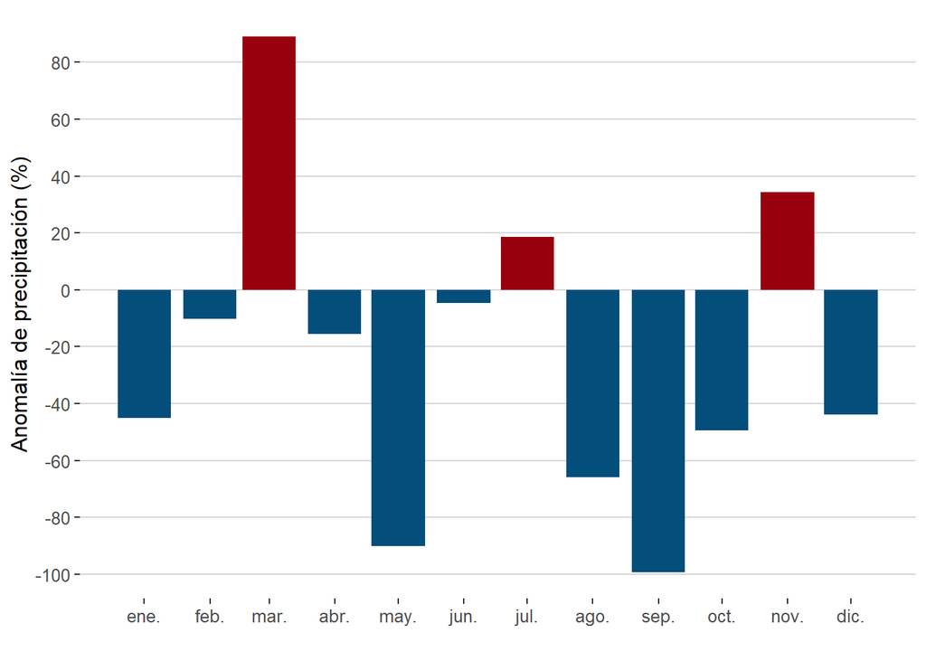

```r
filter(data, yr == 2018) %>%
   ggplot(aes(date, anom, fill = sign)) +
       geom_bar(stat = "identity", show.legend = FALSE) +
    scale_x_date(date_breaks = "month", date_labels = "%b") +
    scale_y_continuous(breaks = seq(-100, 100, 20)) +
    scale_fill_manual(values = c("#99000d", "#034e7b")) +
         labs(y = "Anomalía de precipitación (%)", x = "") +
          theme_hc()
```

### Paso 4: calcular las medidas estadísticas

En este último paso estimamos el valor máximo, mínimo, el cuantil 25%/75% y el rango intercuartil por mes de toda la serie temporal.

```r
data_norm <-     group_by(data, mo) %>%
                     summarise(mx = max(anom),
                               min = min(anom),
                               q25 = quantile(anom, .25),
                               q75 = quantile(anom, .75),
                               iqr = q75-q25)

data_norm
```

```
## # A tibble: 12 x 6
##    mo       mx    min   q25   q75   iqr
##  * <ord> <dbl>  <dbl> <dbl> <dbl> <dbl>
##  1 ene    193.  -89.6 -43.6 56.3   99.9
##  2 feb    320.  -96.5 -51.2 77.7  129.
##  3 mar    381. -100   -40.6 88.2  129.
##  4 abr    198.  -93.6 -51.2 17.1   68.3
##  5 may    141.  -90.1 -45.2 17.0   62.2
##  6 jun    419.  -99.3 -58.2 50.0  108.
##  7 jul    311.  -98.2 -77.3 27.1  104.
##  8 ago    264. -100   -68.2 39.8  108.
##  9 sep    241.  -99.2 -64.9 48.6  113.
## 10 oct    220.  -99.0 -54.5  4.69  59.2
## 11 nov    137.  -98.8 -44.0 39.7   83.7
## 12 dic    245.  -91.8 -49.8 36.0   85.8
```

## Crear el gráfico

Para crear el gráfico de anomalías con leyenda es necesario separar el gráfico principal de las leyendas.

### Parte 1

En esta primera parte vamos añadiendo capa por capa los diferentes elementos: 1) el rango de anomalías máximo-mínimo 2) el rango intercuartil 3) las anomalías del año 2018.

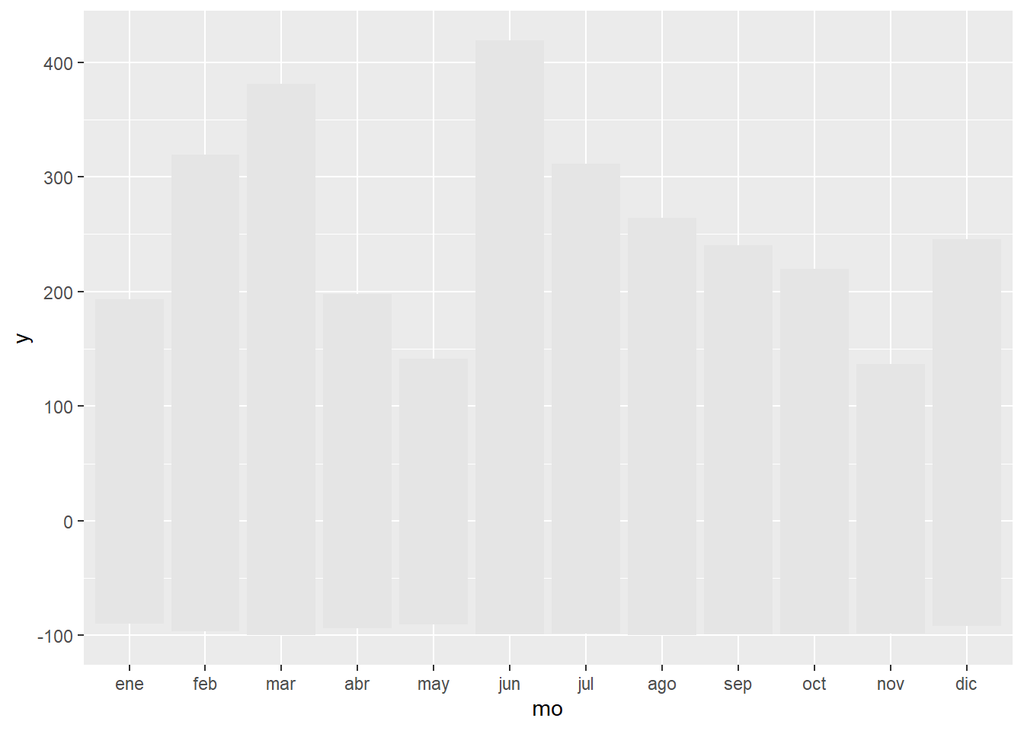

```r
#rango de anomalías máximo-mínimo
g1.1 <- ggplot(data_norm)+
           geom_crossbar(aes(x = mo, y = 0, ymin = min, ymax = mx),
                        fatten = 0, fill = "grey90", colour = "NA")

g1.1
```

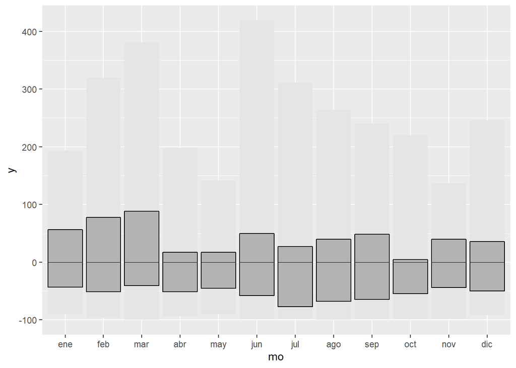

```r
#añadinos el rango intercuartil
g1.2 <- g1.1 + geom_crossbar(aes(x = mo, y = 0, ymin = q25, ymax = q75),
                              fatten = 0, fill = "grey70")

g1.2
```

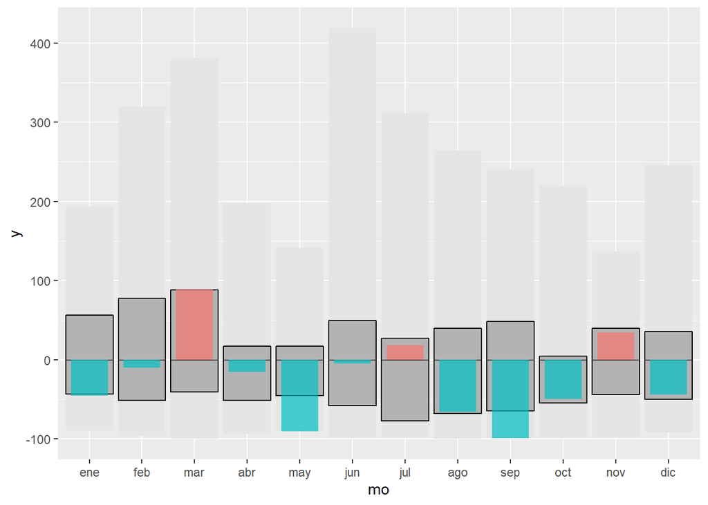

```r
#añadimos las anomalías del año 2018

g1.3 <- g1.2 + geom_crossbar(data = filter(data, yr == 2018),
                aes(x = mo, y = 0, ymin = 0, ymax = anom, fill = sign),
                fatten = 0, width = 0.7, alpha = .7, colour = "NA",
                show.legend = FALSE)
g1.3
```

Finalmente añadimos unos últimos ajustes de estilo.

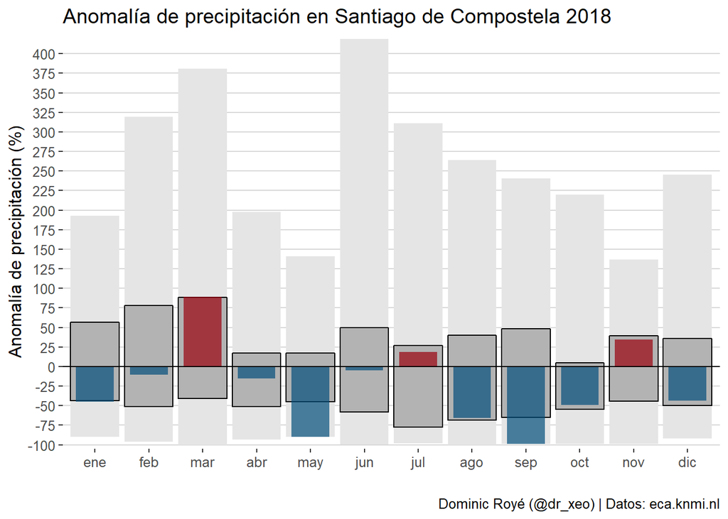

```r
g1 <- g1.3 + geom_hline(yintercept = 0)+
               scale_fill_manual(values=c("#99000d","#034e7b"))+
               scale_y_continuous("Anomalía de precipitación (%)",
                                   breaks = seq(-100, 500, 25),
                                   expand = c(0, 5))+
            labs(x = "",
                 title = "Anomalía de precipitación en Santiago de Compostela 2018",
                 caption="Dominic Royé (@dr_xeo) | Datos: eca.knmi.nl")+
            theme_hc()
g1
```

### Parte 2

Todavía nos falta una leyenda. Primero la creamos para los valores normales.

```r
#datos de la leyenda
legend <- filter(data_norm, mo == "ene")

legend_lab <- gather(legend, stat, y, mx:q75) %>%
                 mutate(stat = factor(stat, stat, c("máximo",
                                                   "mínimo",
                                                   "Cuantil 25%",
                                                   "Cuantil 75%")) %>%
                                            as.character())
```

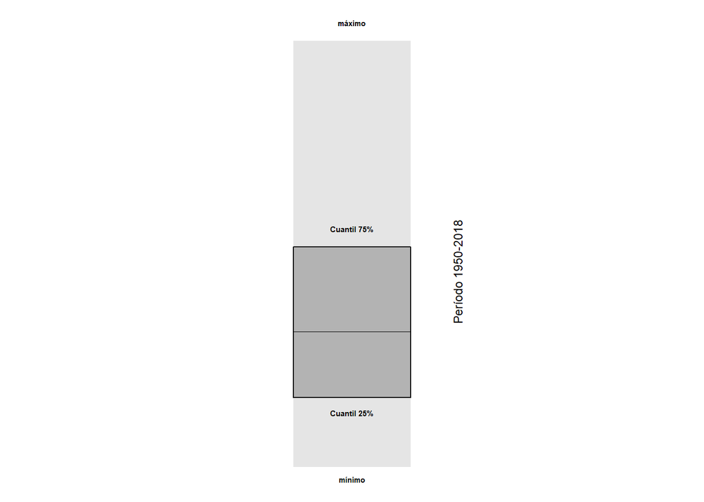

```r
#gráfico de la leyenda
g2 <- legend %>% ggplot()+
                  geom_crossbar(aes(x = mo, y = 0, ymin = min, ymax = mx),
                                fatten = 0, fill = "grey90", colour = "NA", width = 0.2) +
                  geom_crossbar(aes(x = mo, y = 0, ymin = q25, ymax = q75),
                                fatten = 0, fill = "grey70", width = 0.2) +
                  geom_text(data = legend_lab,
                            aes(x = mo, y = y+c(12,-8,-10,12), label = stat),
                            fontface = "bold", size = 2) +
                   annotate("text", x = 1.18, y = 40,
                            label = "Período 1950-2018", angle = 90, size = 3) +
              theme_void() +
                theme(plot.margin = unit(c(0, 0, 0, 0), "cm"))

g2
```

Segundo, creamos otra leyenda para las anomalías actuales.

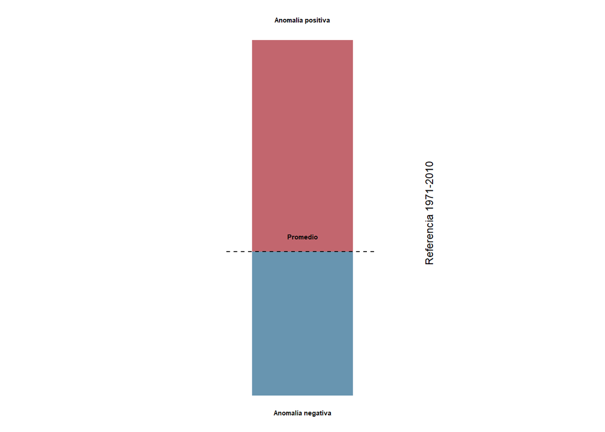

```r
legend2 <- filter(data, yr == 1950, mo %in% c("ene","feb")) %>%
              ungroup() %>%
            select(mo, anom, sign)

legend2[2,1] <- "ene"

legend_lab2 <- data.frame(mo = rep("ene", 3),
                          anom= c(110, 3, -70),
                          label = c("Anomalía positiva", "Promedio", "Anomalía negativa"))

g3 <-  ggplot() +
         geom_bar(data = legend2,
                aes(x = mo, y = anom, fill = sign),
                   alpha = .6, colour = "NA", stat = "identity", show.legend = FALSE, width = 0.2) +
         geom_segment(aes(x = .85, y = 0, xend = 1.15, yend = 0), linetype = "dashed") +
         geom_text(data = legend_lab2, aes(x = mo, y = anom+c(10,5,-13), label = label), fontface = "bold", size = 2) +
         annotate("text", x = 1.25, y = 20,
                  label ="Referencia 1971-2010", angle = 90, size = 3) +
         scale_fill_manual(values = c("#99000d", "#034e7b")) +
        theme_void() +
         theme(plot.margin = unit(c(0, 0, 0, 0), "cm"))

g3
```

### Parte 3

Para finalizar sólo debemos unir el gráfico y las leyendas con ayuda del paquete `cowplot`. La función princial de `cowplot` es `plot_grid()` que ayuda en combinar diferentes gráficos. No obstante, en este caso se hace necesario usar unas funciones más flexibles para crear formatos menos habituales. La función `ggdraw()` configura la capa básica del gráfico, y las funciones que están destinadas a operar en esta capa comienzan con `draw_*`.

```r
p <- ggdraw() +
       draw_plot(g1, x = 0, y = .3, width = 1, height = 0.6) +
       draw_plot(g2, x = 0, y = .15, width = .2, height = .15) +
       draw_plot(g3, x = 0.08, y = .15, width = .2, height = .15)

p
```

[figure not shown]

```r
save_plot("pr_anomalia2016_scq.png", p, dpi = 300, base_width = 12.43, base_height = 8.42)
```

## Múltiples facetas

En este apartado haremos el mismo gráfico como en el anterior, pero para varios años.

### Parte 1

Únicamente debemos filtrar por un conjunto de años, en este caso de 2016 a 2018, usando el operador `%in%`, además añadimos la función `facet_grid()` a `ggplot`, lo que nos permite plotear los gráficos según una variable. La formula usada para la función de facetas es similar al uso en modelos: `variable_por_fila ~ variable_por_columna`. Cuando no tenemos una variable en columna debemos usar el `.`.

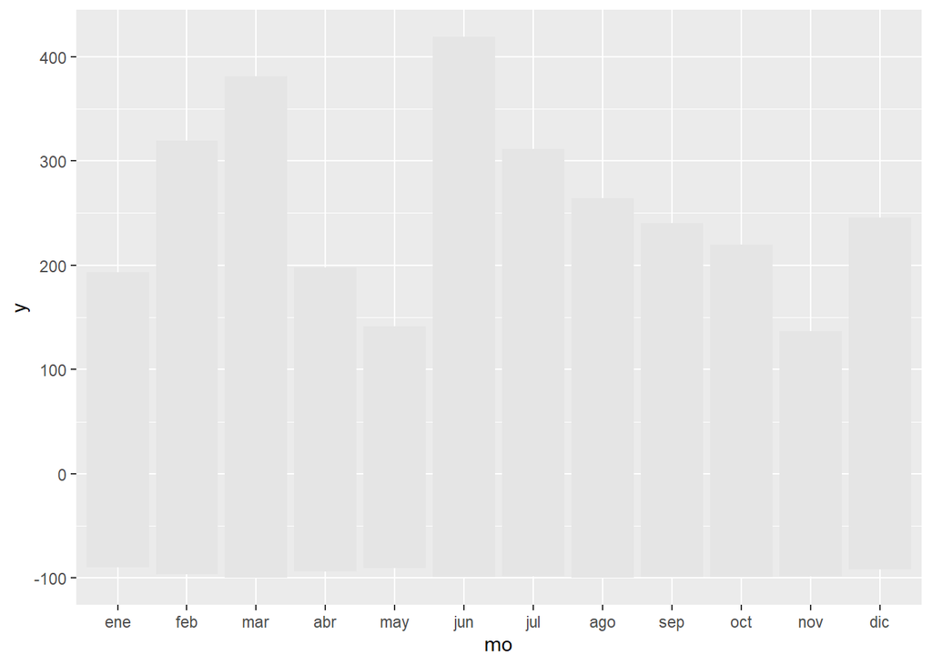

```r
#rango de anomalias maximo-minimo
g1.1 <- ggplot(data_norm)+
           geom_crossbar(aes(x = mo, y = 0, ymin = min, ymax = mx),
                        fatten = 0, fill = "grey90", colour = "NA")

g1.1
```

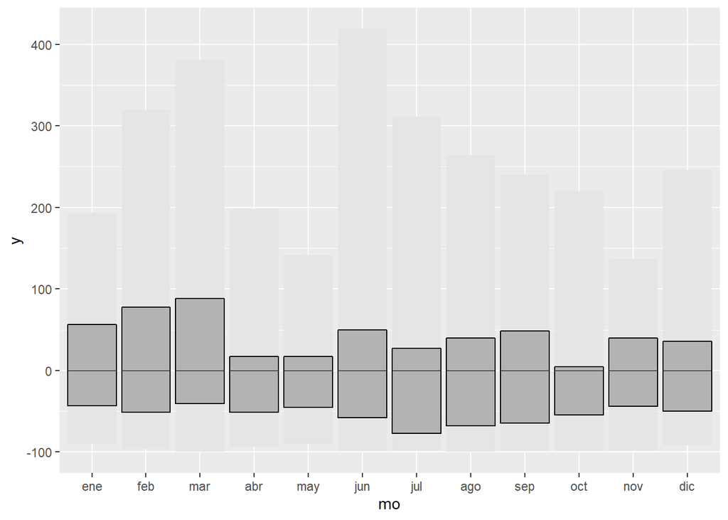

```r
#añadinos el rango intercuartil
g1.2 <- g1.1 + geom_crossbar(aes(x = mo, y = 0, ymin = q25, ymax = q75),
                              fatten = 0, fill = "grey70")

g1.2
```

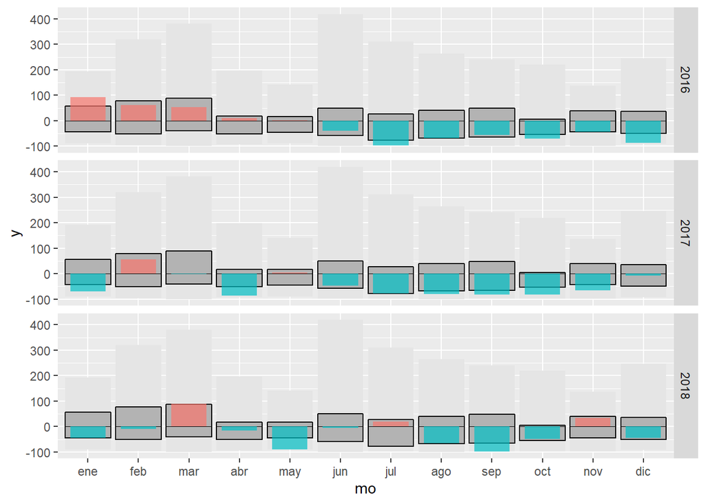

```r
#añadimos las anomalías del año 2016-2018

g1.3 <- g1.2 + geom_crossbar(data = filter(data, yr %in% 2016:2018),
                aes(x = mo, y = 0, ymin = 0, ymax = anom, fill = sign),
                fatten = 0, width = 0.7, alpha = .7, colour = "NA",
                show.legend = FALSE) +
               facet_grid(yr ~ .)
g1.3
```

Finalmente, añadimos unos últimos ajustes de estilo.

```r
g1 <- g1.3 + geom_hline(yintercept = 0)+
               scale_fill_manual(values=c("#99000d","#034e7b"))+
               scale_y_continuous("Anomalía de precipitación (%)",
                                   breaks = seq(-100, 500, 50),
                                   expand = c(0, 5))+
            labs(x = "",
                 title = "Anomalía de precipitación en Santiago de Compostela",
                 caption="Dominic Royé (@dr_xeo) | Datos: eca.knmi.nl")+
            theme_hc()
g1
```

[figure not shown]

Usamos la misma leyenda universal creada para el gráfico anterior.

## Parte 2

Para finalizar, sólo unimos el gráfico y las leyendas con ayuda del paquete `cowplot`. Lo único que debemos ajustar aquí son los argumentos en la función `draw_plot()` para colocar correctamente las diferentes partes.

```r
p <- ggdraw() +
       draw_plot(g1, x = 0, y = .18, width = 1, height = 0.8) +
       draw_plot(g2, x = 0, y = .08, width = .2, height = .15) +
       draw_plot(g3, x = 0.08, y = .08, width = .2, height = .15)

p
```

[figure not shown]

```r
save_plot("pr_anomalia20162018_scq.png", p, dpi = 300, base_width = 12.43, base_height = 8.42)
```